# Single-cell RNAseq Workshop

Differential expression and experimental design

Daniel Bautista

Single-cell genomics workshop · Day 3 Session 2

2026-10-22

## Recap and today’s goals

- Day 1: Single cell basics, Seurat object
- Day 2: QC, normalization, integration, dimensional reduction, and clustering
- Day 3 Session 1: marker genes, manual and reference-based (SingleR) annotation
- Today at session 2:
  1. Differential expression (DE)
  2. Experimental design
  3. Trajectories, cell communication, spatial, …

**Note**

Session 1 compared **clusters** (markers). Today we compare **conditions** within a cell type: will the difference hold in new animals?

## Bulk vs single-cell differential expression

|  | Bulk RNA-seq | scRNA-seq |
| --- | --- | --- |
| One library | one sample | thousands of cells from one sample |
| Conditions | defined by the design | defined by the design (here: FACS sorting) |
| Cell types | mixed together in each sample | **defined from the expression data** (clustering + annotation) |
| A “DE gene” can be | expression **or** composition change | separated: expression (DE) vs proportion (DA) |
| DE tools | DESeq2 / edgeR / limma | the same tools, on **pseudobulk** |

## Which values do we test? Raw counts

```r
Layers(seu[["RNA"]])
```

```
#> "counts"  "data"  "scale.data"
```

| Layer | What it holds | Use |
| --- | --- | --- |
| `counts` | raw UMI counts | pseudobulk sums these |
| `data` | log-normalized per cell | `FindMarkers` default |
| `scale.data` | z-scores HVGs | PCA and heatmaps |
| integrated / corrected | values adjusted to remove sample differences | for clustering and UMAP |

- DESeq2, edgeR need counts

# The experiment

## Chimeric embryos (Pijuan-Sala et al. 2019)

- td-Tomato+ **wild-type** ESCs injected into **wild-type** blastocysts → chimeric embryos at E8.5
- 6–7 embryos pooled and dissociated, then FACS-sorted:
  - **tomato+** → “injected” cells (samples 5, 7, 9)
  - **tomato−** → “host” cells (samples 6, 8, 10)
- Repeated for **3 independent pools** (3, 4, 5)

**What do we expect?**

Both populations are wild-type. If injection doesn’t disturb development, we expect **few differences** within each cell type.

## The design: paired by pool

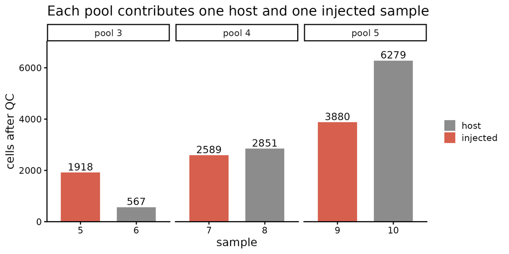

- Each pool gives **one host + one injected** sample, processed together → **paired design**
- The replicate is the **pool**: n = 3 per condition

## Load the object

```r
library(Seurat)
library(tidyverse)
library(edgeR)                  # bulk RNA-seq DE, used on the pseudobulk

seu <- readRDS("/varidata/researchtemp/hpctmp/single_cell_workshop_2026/day2/data/day2_session2_seu.rds")

DefaultAssay(seu) <- "RNA"      # DE uses the RNA assay, never the integrated values
seu <- JoinLayers(seu)          # Day 2 split the layers by sample; join them again

# remove cells the published annotation flags as doublets or "stripped" nuclei
seu <- subset(seu, subset = !celltype.mapped %in% c("Doublet", "Stripped"))
```

**Tip**

Restart R before this session

## Define the condition

```r
# tomato = TRUE  -> cell comes from the injected td-Tomato+ stem cells
# tomato = FALSE -> cell comes from the host embryo
seu$injection <- ifelse(seu$tomato, "injected", "host")
seu$injection <- factor(seu$injection, levels = c("host", "injected"))   # host = reference

# seu[[]] is the cell metadata table
seu[[]] |> distinct(sample, pool, injection) |> arrange(pool)

table(seu$sample)                # cells per sample
```

```
#>    5    6    7    8    9   10
#> 1918  567 2589 2851 3880 6279
```

- **host** is the reference level, so fold changes read “injected vs host”

## Host and injected cells share the same map

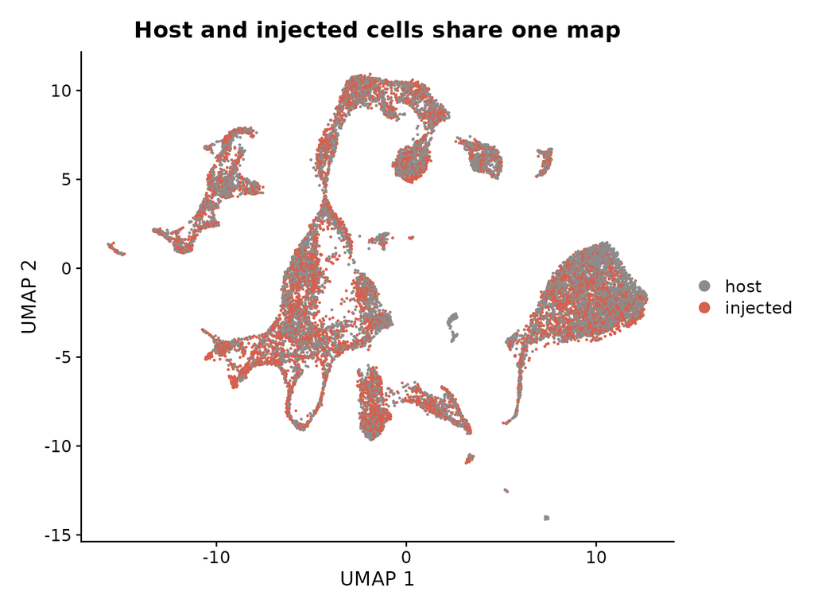

```r
DimPlot(seu, reduction = "umap", group.by = "injection",
             shuffle = TRUE,
             cols = c("grey55", "#d6604d"), pt.size = 0.2)
```

# Comparing conditions

## Three different questions

| Question | Analysis | Replicate unit | Tool |
| --- | --- | --- | --- |
| What distinguishes cluster X? | **Markers** (Session 1) | cells | `FindAllMarkers` |
| Does cell type X change between conditions? | **Differential expression** | **samples** | pseudobulk + edgeR |
| Does the proportion of X change? | **Differential abundance** | **samples** | cell counts + edgeR |

## Cell types come from the data: what does that mean for DE?

- Cell types were **defined from expression**
- It uses **the same expression values** we later test

| Comparison | Groups defined by |  |
| --- | --- | --- |
| Cluster A vs cluster B (markers) | the expression data |  |
| Injected vs host **within** a cell type | the design (FACS sorting) |  |

## Where are the Mesenchyme cells?

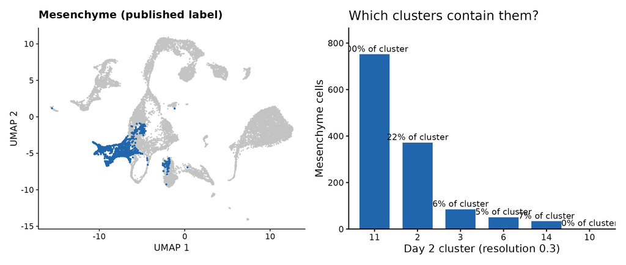

- `celltype.mapped` was assigned **cell by cell**

## Two ways to compare conditions

1. **Per cell**: `FindMarkers`, treating each cell as an independent observation
2. **Pseudobulk**: sum the cells of each sample, then compare **samples**

## Per cell: `FindMarkers`

```r
mes <- subset(seu, subset = celltype.mapped == "Mesenchyme")
table(mes$sample)                     # Mesenchyme cells per sample
```

```
#>   5   6   7   8   9  10
#> 218  28 208 123 439 281
```

```r
# the same function as in Session 1, now comparing conditions
Idents(mes) <- "injection"
sc_de <- FindMarkers(mes, ident.1 = "injected", ident.2 = "host",
                     logfc.threshold = 0,   # test all genes, no fold-change cut-off
                     min.pct = 0.1)         # detected in at least 10 % of cells in one group
sum(sc_de$p_val_adj < 0.05)           # how many significant genes?
```

```
#> [1] 403
```

- **403** significant genes, in a comparison where we expected few

## A control comparison: host vs host

```r
# keep only two HOST samples: no condition difference between them
host_only <- subset(mes, subset = injection == "host" & sample %in% c(6, 8))

Idents(host_only) <- "sample"         # compare sample 6 vs sample 8
fake_de <- FindMarkers(host_only, ident.1 = "6", ident.2 = "8",
                       logfc.threshold = 0, min.pct = 0.1)
sum(fake_de$p_val_adj < 0.05)
```

```
#> [1] 125
```

- These are differences between samples (embryo pool, dissociation, capture), which a per-cell test can’t separate from a condition effect

# Pseudobulk differential expression

## Aggregate the counts per sample and cell type

```r
# Sum the RAW counts of all cells that share a cell type AND a sample.
# pool and injection are fixed within a sample: listing them adds no groups,
# it just keeps them as metadata columns.
pseudo <- AggregateExpression(seu,
                              assays = "RNA",
                              return.seurat = TRUE,
                              group.by = c("celltype.mapped", "sample", "pool", "injection"))
pseudo$injection <- factor(pseudo$injection, levels = c("host", "injected"))
head(pseudo[[]])                    # one row per pseudobulk sample

# how many cells were summed into each pseudobulk sample?
n_cells <- table(seu$celltype.mapped, seu$sample)                 # cell type x sample
pseudo$ncells <- as.vector(n_cells[cbind(pseudo$celltype.mapped,  # row = cell type
                                         pseudo$sample)])         # column = sample

# drop pseudobulk samples built from fewer than 10 cells (too noisy)
pseudo <- subset(pseudo, subset = ncells >= 10)

mes_pseudo <- subset(pseudo, subset = celltype.mapped == "Mesenchyme")
```

## Filter and normalize

```r
# DGEList = edgeR's container: counts + a table describing the samples
y <- DGEList(counts  = as.matrix(LayerData(mes_pseudo, assay = "RNA", layer = "counts")),
             samples = mes_pseudo[[]])

# keep genes with enough counts to be tested
keep <- filterByExpr(y, group = y$samples$injection)
summary(keep)
```

```
#>    Mode   FALSE    TRUE
#> logical   19511    9942
```

```r
y <- y[keep, , keep.lib.sizes = FALSE]

y <- normLibSizes(y)          # TMM normalization, as in bulk RNA-seq
plotMDS(y)                       # how similar are the samples?
```

- The per-cell normalization from Day 2 is **not** used: edgeR normalizes the pseudobulk itself

## Look at the samples first: MDS

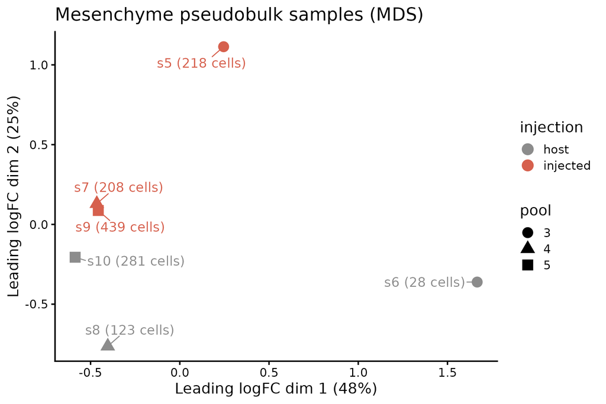

## The model: block on pool, test injection

```r
# expression ~ pool + injection: compare injected vs host WITHIN each pool
design <- model.matrix(~ factor(pool) + injection, data = y$samples)
colnames(design)
```

```
#> "(Intercept)" "factor(pool)4" "factor(pool)5" "injectioninjected"
```

```r
y   <- estimateDisp(y, design)                     # variation between replicates
fit <- glmQLFit(y, design, robust = TRUE)          # fit the model for every gene
res <- glmQLFTest(fit, coef = "injectioninjected") # test the injection effect

summary(decideTests(res))                          # DEGs at FDR 5 %
```

```
#>        injectioninjected
#> Down                   5
#> NotSig              9930
#> Up                     7
```

```r
topTags(res)                                       # top 10 genes
```

- **12 DEGs**, compared with 403 from the per-cell test

## Variation between replicates (BCV)

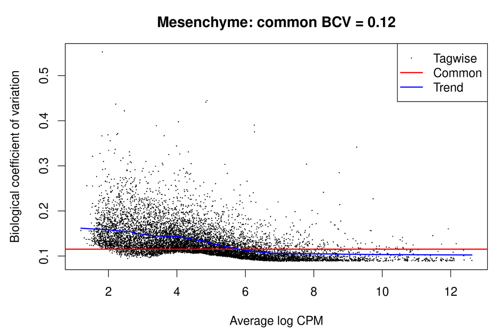

## Top genes in Mesenchyme

| gene | logFC | logCPM | FDR |
| --- | --- | --- | --- |
| Cdkn1c | −6.88 | 7.6 | 4.6e-09 |
| Xist | −7.56 | 6.4 | 1.1e-06 |
| Erdr1 | 2.05 | 7.9 | 2.0e-05 |
| **tomato-td** | **7.38** | 4.4 | 4.8e-05 |
| Mid1 | 1.48 | 6.0 | 1.5e-03 |
| H13 | −1.12 | 6.7 | 2.0e-03 |
| Zdbf2 | 1.64 | 6.0 | 2.7e-03 |
| Kcnq1ot1 | 1.31 | 6.3 | 8.7e-03 |
| Akr1e1 | −1.65 | 4.2 | 9.0e-03 |
| Nnat | 0.84 | 9.8 | 1.0e-02 |

## Closer look

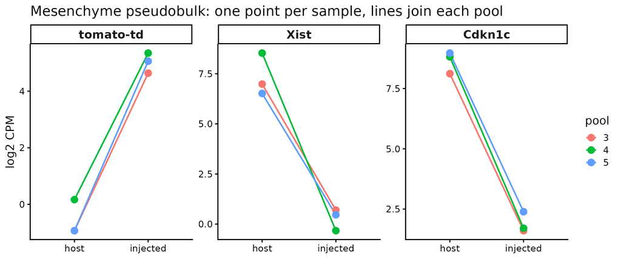

## DE comparison

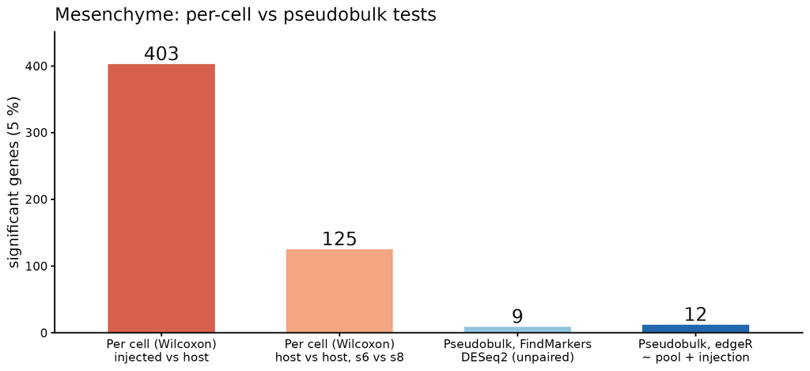

- Per-cell tests find many more genes

# All cell types

## The same steps for every cell type

```r
# the Mesenchyme steps, wrapped in a function. pb = pseudobulk of ONE cell type
run_edger <- function(pb) {
  if (min(table(pb$injection)) < 2) return(NULL)        # need >= 2 samples per condition
  y <- DGEList(counts  = as.matrix(LayerData(pb, assay = "RNA", layer = "counts")),
               samples = pb[[]])
  design <- model.matrix(~ factor(pool) + injection, data = y$samples)
  if (nrow(design) <= ncol(design)) return(NULL)        # need more samples than model terms
  y <- y[filterByExpr(y, group = y$samples$injection), , keep.lib.sizes = FALSE]
  y <- normLibSizes(y)
  y <- estimateDisp(y, design)
  res <- glmQLFTest(glmQLFit(y, design, robust = TRUE), coef = "injectioninjected")
  tab <- topTags(res, n = Inf)$table
  tab$gene <- rownames(tab)
  tab
}

de_list <- list()
for (ct in unique(pseudo$celltype.mapped)) {
  res_ct <- run_edger(subset(pseudo, subset = celltype.mapped == ct))
  if (!is.null(res_ct)) de_list[[ct]] <- res_ct          # keep only testable cell types
}
de_all <- bind_rows(de_list, .id = "celltype")           # one long table, all genes
```

- 22 cell types could be tested
- Untested ≠ unchanged

## How many DEGs per cell type?

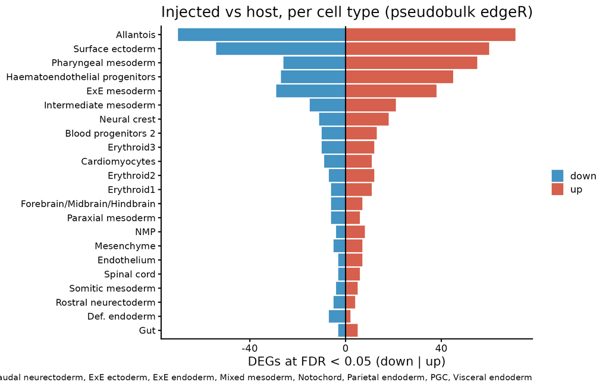

## Genes that change everywhere

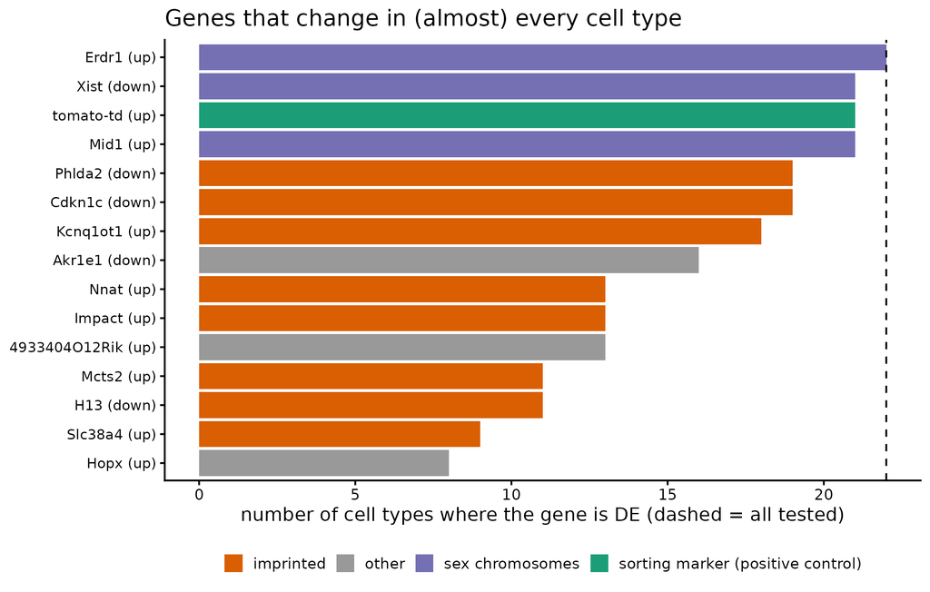

- **tomato-td**: positive control (sorting marker)
- **Xist down**: the ESC line is **male**; host embryos are male and female
- **Imprinted genes** (Kcnq1ot1 up; Cdkn1c, Phlda2 down; …): imprinting drift in the cultured ESC line

## Differential abundance: do proportions change?

```r
# count cells per cell type (rows) and sample (columns)
abundances <- unclass(table(seu$celltype.mapped, seu$sample))

# one row per sample, in the same order as the columns
sample_info <- seu[[]] |> distinct(sample, pool, injection) |> arrange(sample)
sample_info <- sample_info[match(colnames(abundances), sample_info$sample), ]

# the same edgeR model, on cell numbers instead of gene counts
y.ab <- DGEList(abundances, samples = sample_info)
y.ab <- y.ab[filterByExpr(y.ab, group = y.ab$samples$injection), ]
design.ab <- model.matrix(~ factor(pool) + injection, y.ab$samples)
y.ab   <- estimateDisp(y.ab, design.ab, trend = "none")
fit.ab <- glmQLFit(y.ab, design.ab, robust = TRUE, abundance.trend = FALSE)
topTags(glmQLFTest(fit.ab, coef = "injectioninjected"))
```

## Differential abundance

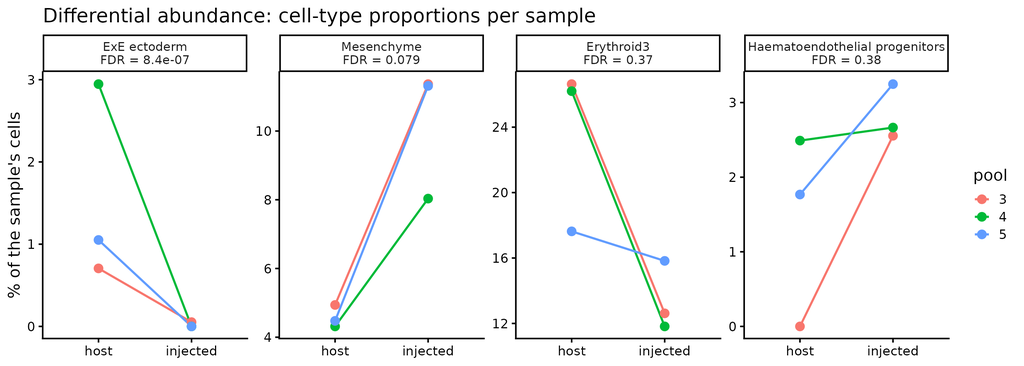

- **ExE ectoderm** is nearly absent from injected cells: ESCs don’t contribute to extra-embryonic tissue (a positive control)
- Proportions are linked: when one cell type goes down, all others go up a little (**composition effect**)

## GSEA

```r
library(fgsea)
library(msigdbr)

# mouse Hallmark gene sets (older msigdbr versions: category = "H")
hallmark <- msigdbr(species = "Mus musculus", collection = "H")
pathways <- split(hallmark$gene_symbol, hallmark$gs_name)   # pathway -> genes

# rank ALL tested genes: + higher in injected, - lower in injected
mes_table <- topTags(res, n = Inf)$table
ranks <- sign(mes_table$logFC) * -log10(mes_table$PValue)
names(ranks) <- rownames(mes_table)
ranks <- sort(ranks, decreasing = TRUE)

gsea_res <- fgsea(pathways = pathways, stats = ranks, minSize = 15, maxSize = 500)
head(gsea_res[order(gsea_res$pval), ])
```

## GSEA result

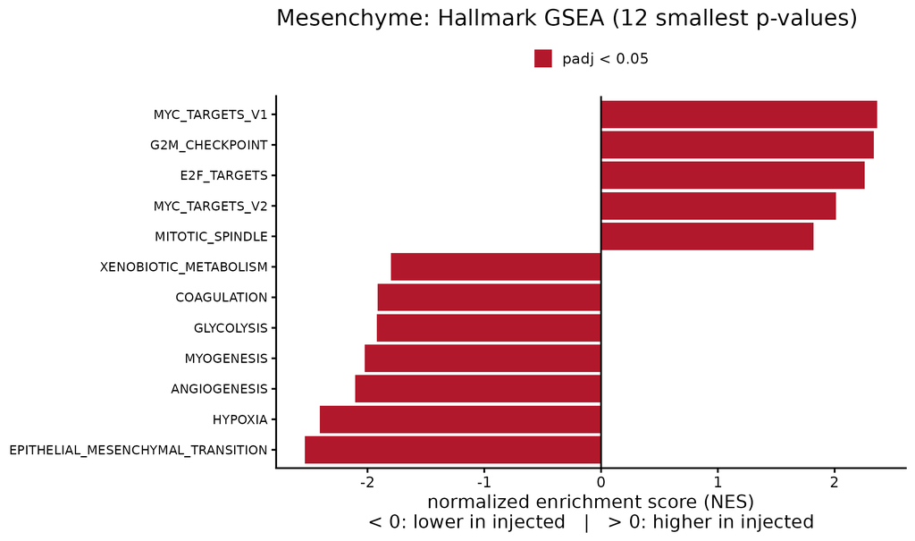

## Pitfalls checklist

- Use pseudobulk for condition comparisons
- Use **Raw counts**, after `JoinLayers()`
- Drop pseudobulk samples with too few cells
- Put pairing/batch **in the design**
- Check **sex genes** (Xist, Ddx3y, Eif2s3y, Kdm5d, Uty) and **ambient RNA**
- Labels come from the data: check **DA** alongside DE
- Seurat `avg_log2FC` ≠ edgeR `logFC`

## Save the results

```r
if (!dir.exists("res")) {
  dir.create("res")
}

# all genes, all tested cell types
write.csv(de_all, "res/DE_injected_vs_host_pseudobulk_edgeR.csv", row.names = FALSE)

# how many cells went into each pseudobulk sample
write.csv(pseudo[[]], "res/pseudobulk_ncells.csv", row.names = FALSE)

# package versions
writeLines(capture.output(sessionInfo()), "res/sessionInfo.txt")
```

# Experimental design tips

## What counts as a replicate

1. **1,000 cells from 1 animal is n = 1**: cells are measurements *within* a replicate
2. More cells per sample still help: **more precise mean estimates → more power**
3. Technical replicates (one sample over two lanes) add no biological *n*
4. Pooling animals averages them, but each pool is **one** replicate (our chimera pools)

## Depends on the model

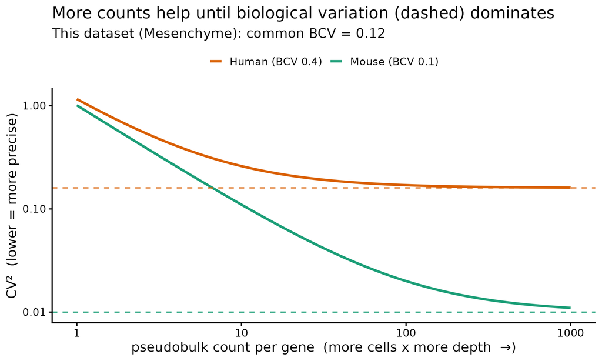

| μ = 20 → | Mouse | Human |
| --- | --- | --- |
| baseline CV² | 0.060 | 0.210 |
| 2× cells or depth | **−42 %** | −12 % |
| 10× counts | −75 % | −21 % |
| 2× replicates | −50 % | −50 % |

Mouse BCV ≈ 0.1; human ≈ 0.4 (edgeR guide). **This dataset: 0.12.**

## Summary

- **More biological replicates always add power**
- **Mice have much smaller BCVs than humans** → fewer animals can be enough
- **Depth can partly compensate for replicates**, more so the smaller the BCV
- For a fixed budget, **many cells sequenced shallowly** usually beat few cells sequenced deeply (scPower, Schmid et al. 2021)
- **More detected genes → slightly lower power**: the same UMIs spread over more genes means lower counts per gene
  - Day 2: samples 5 and 6 had many features per cell

## Rare cell types

```
cells needed per sample  ≈  target cells of that type per sample  ÷  its frequency

1 %   type, 20 cells per sample  →   2,000 cells per sample
0.1 % type, 20 cells per sample  →  20,000 cells per sample
```

- Few cells per pseudobulk get drops while filtering
- Rare types need more samples, more cells and higher depth
- Enrichment before capture (FACS, as with td-Tomato here; depletion of abundant types)

## More analysis using the `seu` object

| Question | Approach | R / Bioconductor | Python (scverse) |
| --- | --- | --- | --- |
| Do proportions change, without fixed clusters? | Differential abundance on neighbourhoods | miloR, sccomp, propeller | Milo, scCODA (pertpy) |
| Order cells along a process | Trajectory / pseudotime | Slingshot, Monocle 3, tradeSeq | PAGA, CellRank |
| Where are cells heading? | RNA velocity | velociraptor | scVelo |
| Which cells talk to each other? | Cell–cell communication | CellChat, NicheNet | LIANA+, CellPhoneDB |

## Regulation, multiple modalities, perturbations

| Question | Approach | R / Bioconductor | Python (scverse) |
| --- | --- | --- | --- |
| Which transcription factors drive the programs? | Gene regulatory networks, TF activity | SCENIC, decoupleR | pySCENIC, decoupler |
| Protein + RNA in the same cell | CITE-seq | Seurat WNN | totalVI, muon |
| Chromatin + RNA in the same cell | Multiome (ATAC + RNA) | Signac, ArchR | MultiVI, muon |
| What does each gene do? | Perturbation screens (Perturb-seq) | Seurat mixscape | pertpy |

## Spatial transcriptomics

| Type | Examples | Resolution | Genes |
| --- | --- | --- | --- |
| Sequencing-based | Visium, **Visium HD**, Slide-seq, Stereo-seq | spots → near single-cell | whole transcriptome |
| Imaging-based | **Xenium**, **MERFISH**, **CosMx** | single-cell / subcellular | panels of hundreds–thousands |

Single cell RNA-seq Workshop - Day 3 session 2